# Orchard Project: Supplementary

#### Colin Brislawn, PNNL, Spring 2017

#### (Includes both 16S and 18S data)

#### About this document

This project makes use of many packages, especially Phyloseq https://joey711.github.io/phyloseq/.

The goal of this document it to provide a comprehensive overview of all methods used in the paper for visualizing amplicon data.

This document is directly based on the methods used in [Trade-offs between microbiome diversity and productivity in a stratified microbial mat](https://github.com/pnnl/bernstein-2016-productivity-and-diversity). Both projects are a collaboration with Hans Bernstein in 2016-2017.

### Setup:

```r
library("checkpoint")
library("knitr")
checkpoint("2016-10-01", use.knitr = T)
```

```
## Scanning for packages used in this project
```

[output not shown]

```
## - Discovered 1 packages
```

```
## Unable to parse 1 files:
```

```
## - OrchardSup.Rmd
```

```
## All detected packages already installed
```

```
## checkpoint process complete
```

```r
library("ggplot2")
library("phyloseq")
# How to install phyloseq:
# 1) Let checkpoint() install as much as possible.
# 2) Run: source('http://bioconductor.org/biocLite.R'); biocLite('phyloseq', suppressUpdates = T)
library("RColorBrewer")
library("viridis")
library("scales")
library("cowplot")
library("vegan")
library("dplyr")
library("lubridate")
library("reshape2")
library("ggrepel")

theme_set(theme_bw())
opts_chunk$set(cache=TRUE, dev = c('png'), warning = F)

# This let's our special characters like ‰ be saved to out pdfs:
pdf.options(encoding = "MacRoman.enc")
# Not sure how well this works cross platforms.
```

```r
packageVersion('phyloseq')
```

```
## [1] '1.20.0'
```

```r
set.seed(711)
```

The function `set.seed()` is used here to provide a reproducible starting point for random number generation. Random sampling is used throughout this document, from `phyloseq::rarefy_even_depth()` to `vegan::adonis()`, and small changes to the order in which sampling is performed could change the results.

### Import data

Our work here will focus on two amplicon data sets. One from the 16S gene, the other from the 18S gene. Because these amplicons came from different primers and are expected to target different genes (of different evolutionary history, length, complexity, etc) they will be analyzed separately. (This also makes the stats simpler.)

```r
no_meta <- import_biom(file.path('../data/16S_otus_vsearch/otu_table_w_tax.biom')
                       #,file.path('../16S/otus_vsearch/rep_set.tre')
                       )
meta <- import_qiime_sample_data(file.path('../metadata/generated-meta.tsv'))
full16s <- merge_phyloseq(meta, no_meta)
full16s
```

```
## phyloseq-class experiment-level object
## otu_table()   OTU Table:         [ 3152 taxa and 99 samples ]
## sample_data() Sample Data:       [ 99 samples by 32 sample variables ]
## tax_table()   Taxonomy Table:    [ 3152 taxa by 7 taxonomic ranks ]
```

```r
no_meta_18s <- import_biom(file.path('../data/18S_otus_vsearch/otu_table_w_tax.biom'))
full18s <- merge_phyloseq(meta, no_meta_18s)
full18s
```

```
## phyloseq-class experiment-level object
## otu_table()   OTU Table:         [ 2838 taxa and 98 samples ]
## sample_data() Sample Data:       [ 98 samples by 32 sample variables ]
## tax_table()   Taxonomy Table:    [ 2838 taxa by 7 taxonomic ranks ]
```

### Explore metadata

Let’s take a look at columns in the metadata file.

**Make major edits to the metadata using the `generate-metadata.Rmd` file.** This file focuses on downstream analysis, while metadata wrangling should have be completed already.

```r
# Let's use 16S, as it's our main focus, and has more samples.

meta <- sample_data(full16s)
meta.n_unique <- rapply(meta, function(x) length(table(x)))
# The pairwise interesting factors
meta.n_unique[meta.n_unique == 2]
# Other potentially interesting factors
meta.n_unique[meta.n_unique > 2 & meta.n_unique < max(meta.n_unique)]

# Main study design:
# 4 Substrates every 6 hours for 48 hours
table(meta$Time..H., meta$Substrate)

meta$rep. <- factor(meta$rep.)

# Reorder levels of Substrate
levels(meta$Substrate)
meta$Substrate <- factor(meta$Substrate, levels = c("13C DIC", "13C Acetate", "13C Glucose", "Control", "Native Mat"))
levels(meta$Substrate)

# Also, rename levels of Substrate
levels(meta$Substrate) <- c("DIC", "Acetate", "Glucose", "Control", "Native Mat")
levels(meta$Substrate)

# Fix import of standard timestamp format
meta$collection_timestamp <- ymd_hms(meta$collection_timestamp)

# Let's keep Time..H. numeric
#meta$Time..H. <- factor(meta$Time..H.)

sample_data(full16s) <- meta
sample_data(full18s) <- meta
```

## Environmental Metadata

This study includes measurements of several environmental variables over 48 hours. Understanding how these vary over time, let us focus on interesting changes.

```r
table(meta$Time..H., meta$Substrate)

head(meta)
#meta.melt <- meta
meta.melt = melt(meta, measure.vars = c("SKNT.mph", "SOLR.W.m.m", "PREC.in", "STEN.centibar", "TMP..C.", "fin_diff_Ave_d13C.organic"))
head(meta.melt)

meta.gg <- ggplot(meta.melt, aes(Time..H., value, color = Time..H.))
meta.gg <- meta.gg +
  #geom_boxplot(color = "gray") + #, outlier.size = 0) +
  geom_jitter(width = 0.1) +
  facet_grid(facets = variable~., scales = "free_y") +
  labs(x = "Time (h)", title = "Environmental factors") +
  #v +
  theme(legend.position = "none",
            strip.background = element_blank(),
            axis.title.y = element_blank())
meta.gg
```

Only substrate, light, and time would realistically effect the sample.

Let’s check out how the measured isotopes changed…

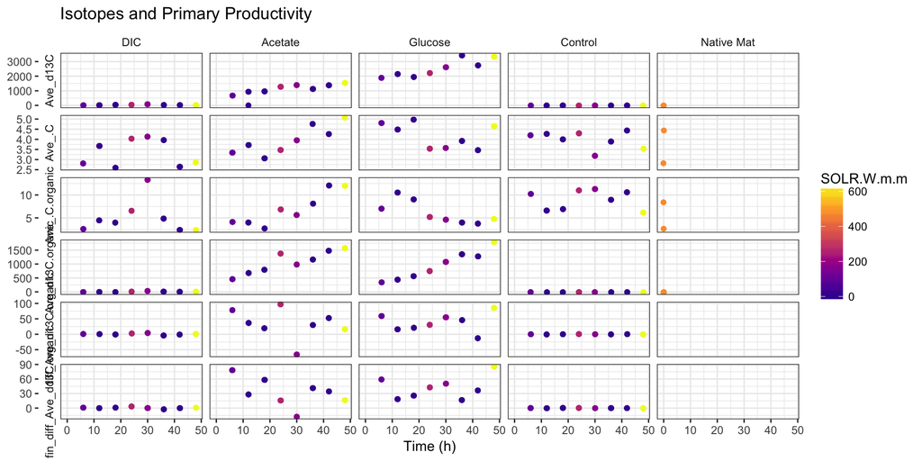

```r
# Sunlight colormap
pl.c <- scale_color_viridis(option = "C", discrete = F, begin = .1, end = 1)

head(meta)
table(meta$Substrate)
meta.melt2 = melt(meta, measure.vars = c("Ave_d13C", "Ave_.C", "Ave_.C.organic", "Ave_d13C.organic", "diff_Ave_d13C.organic", "fin_diff_Ave_d13C.organic"))
head(meta.melt2)
meta.gg2 <- ggplot(meta.melt2, aes(Time..H., value, color = SOLR.W.m.m))
meta.gg2 <- meta.gg2 +
  #geom_boxplot(color = "gray") + #, outlier.size = 0) +
  geom_jitter(width = 0.1) +
  facet_grid(facets = variable~Substrate, scales = "free_y", switch = "y") +
  labs(x = "Time (h)", title = "Isotopes and Primary Productivity") +
  pl.c +
  theme(legend.position = "right",
            strip.background = element_blank(),
            axis.title.y = element_blank()
            #, plot.margin=unit(c(5,5,-25,5), units = "pt")
            )
meta.gg2
```

```r
fig1.a <- ggplot(meta, aes(Time..H., SOLR.W.m.m, color = SOLR.W.m.m))
fig1.a <- fig1.a + geom_line(alpha = 1, color="gray80") + geom_point(size = 1.5) +
  #labs(y = "Ii (Wm^-2)") +
  facet_grid(PREC.in~.) + # This is a single 'dummy' facet so plot_grid() will align it
  scale_color_viridis(option = "C", end = .90) +
  labs(x = "Time (h)", y =
         #expression(atop("Irradiance", "("~ Wm^{-2}~ ")")) # two lines
         expression("Irradiance ("~Wm^{-2}~")") # one line
       ) +
  scale_x_continuous(breaks = c(0, 24, 48), limits = c(0, 48)) +
  theme(
    #axis.title.y = element_text(angle = 0, vjust = .5),
        legend.position = "none",
        strip.text = element_blank(), strip.background = element_blank() # remove 'dummy' facet
        )
fig1.a
```

```r
# only use key Substrates
meta.small <- subset(meta, Substrate %in% c("Glucose", "Acetate", "DIC"))

fig1.b <- ggplot(meta.small, aes(Time..H., fin_diff_Ave_d13C.organic, color = Substrate))
fig1.b <- fig1.b +
  geom_abline(slope = 0, color = "gray66") +
  geom_line(alpha = .4) +
  geom_point() +
  geom_errorbar(aes(ymax = (fin_diff_Ave_d13C.organic + fin_diff_Stdev_d13C.organic), ymin = (fin_diff_Ave_d13C.organic - fin_diff_Stdev_d13C.organic)), width = 0) +
  # Note that we have two error bars. diff_Stdev and diff_Stdev_hourly
  scale_color_brewer(palette = "Set2") +
  facet_grid(Substrate~., scales = "free_y") +
  labs(x = "Time (h)", y =
         expression("Productivity: " ~ Delta~delta^13~C / Delta ~t ~"  (‰"~ h^-1~")") # note this uses the ‰ 'Per_mille' sign
       ) +
  scale_x_continuous(breaks = c(0, 24, 48), limits = c(0, 48)) +
  #geom_text(aes(5, -20, label=Substrate), hjust = 0) +
  theme(strip.background = element_blank(),
        legend.position = "none")
fig1.b
```

#### Figure 1, a b

This figure could be rendered at 5.5 vs 2.4, to fit figure without scaling.

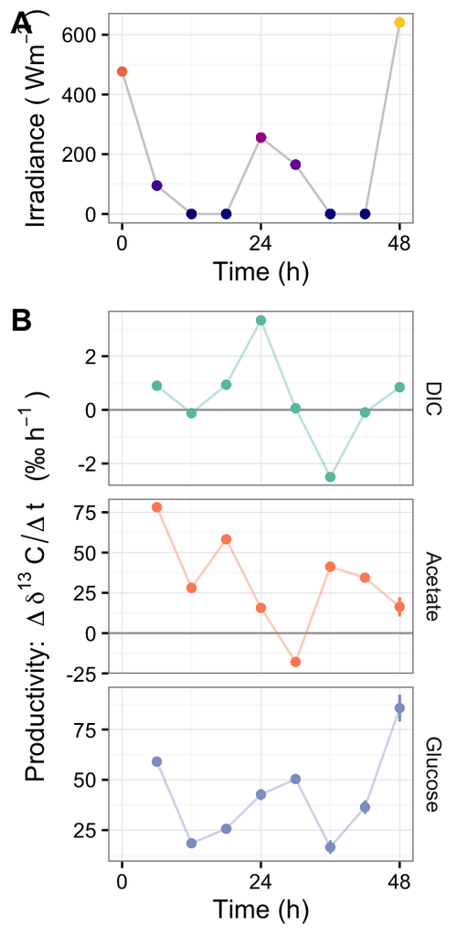

```r
plot_grid(fig1.a, fig1.b, align = "v", rel_heights = c(1.4,3), ncol = 1, labels = c("A", "B"))
```

```r
# this should match the height of fig1-cd and their widths should add to 183
ggsave('fig1-ab.pdf', path = "./figures/", units = "mm", width = 61, height = 122, scale = 1.2)
```

#### Sup Figure 1: productivity vs irradiance

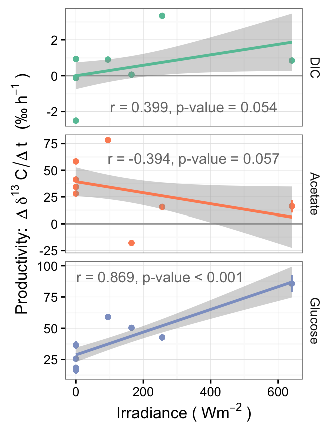

```r
# Let's see if we can add slopes and p-values to these graphs
# See https://stackoverflow.com/questions/17022553/adding-r2-on-graph-with-facets


# Example data for testing function
df <- data.frame(meta.small[meta.small$Substrate == "Glucose", ])
head(df)
dim(df)

lm_eqn_lighvsc = function(df){
    pearson <- cor.test(df$SOLR.W.m.m, df$fin_diff_Ave_d13C.organic, method = "pearson", conf.level = 0.95)
    pearson
    pearson$p.value # this p-value matches the one from summary(lm())$coefficients
    pearson$estimate

    eq <- substitute(
      # This text parsing here is poor.
      #atop("slope ="~slope, "p-value ="~pv), # Two lines
      #~~R^2~"="~r2~", p-value "~pv, # with R^2
      "r ="~r~"p-value"~pv, # One line
      list(
        r = paste(signif(pearson$estimate, digits = 3), ",", sep = ""),
        pv = if(pearson$p.value <= 0.001) pv = "< 0.001" else pv = paste("= ", sprintf(fmt = "%.3f", pearson$p.value), sep = "")
      )
    )
    as.character(as.expression(eq))
}

# Make a matching data frame with these calculated values
# This is based on the stackoverflow answer, and on the Bile Acids graphs
# See Lactobacillus acidophilus disrupts multispecies synthesis of a secondary bile acid ursocholate
# Hans C. Bernstein, PNNL, 2017

eqns <- by(data.frame(meta.small), INDICES = list(meta.small$Substrate), lm_eqn_lighvsc)
#eqns

df2 <- data.frame(eq = c(eqns),
                  Substrate = c("DIC", "Acetate", "Glucose"),
                  graphx = c(350, 350, 250),
                  graphy = c(-1.8, 60, 90))
df2


fig.pvi <- ggplot(meta.small, aes(SOLR.W.m.m, fin_diff_Ave_d13C.organic, color = Substrate))
fig.pvi <- fig.pvi +
  geom_abline(slope = 0, color = "gray66") +
  geom_point() +
  geom_smooth(method = "lm") +
  geom_errorbar(aes(ymax = (fin_diff_Ave_d13C.organic + fin_diff_Stdev_d13C.organic), ymin = (fin_diff_Ave_d13C.organic - fin_diff_Stdev_d13C.organic)), width = 0) +
  # Note that we have two error bars. diff_Stdev and diff_Stdev_hourly
  scale_color_brewer(palette = "Set2") +           # use with color = Substrate
  #scale_color_viridis(option = "C", end = .90) +  # use with color = SOLR.W.m.m
  facet_grid(Substrate~., scales = "free_y") +
  geom_text(data = df2, aes(x = graphx, y = graphy, label = eq), color = '#777777', parse = TRUE) +
  labs(x = expression("Irradiance ("~ Wm^{-2}~ ")")
       ,y=expression("Productivity: " ~ Delta~delta^13~C / Delta ~t ~"  (‰"~ h^-1~")")
       ) +
  #geom_text(aes(5, -20, label=Substrate), hjust = 0) +
  theme(strip.background = element_blank(),
        legend.position = "none")
fig.pvi
```

```r
ggsave('fig-sup.pdf', path = "./figures/", units = "mm", width = 89, height = 120, scale = 1)
```

## Preprocess

Remove all non-bacteria microbes, along with OTUs annotated as chloroplasts or mitochondria.

Inspect sample sizes and rarefy….

Also create cohort of Time > 0 samples. We may not want to include the initial three samples.

#### 16S

```r
filtered16s <- subset_taxa(full16s, Rank1 == "k__Bacteria")
ntaxa(filtered16s) / ntaxa(full16s)
sum(taxa_sums(filtered16s)) / sum(taxa_sums(full16s))

# Why are we losing so many reads?

nonbacteria.16s <- subset_taxa(full16s, Rank1 != "k__Bacteria")
plot_bar(nonbacteria.16s, fill = "Rank1")
```

```r
# Not NOT Archaea. It's mostly unnown microbes...

plot(sort(taxa_sums(nonbacteria.16s)))
```

```r
head(sort(taxa_sums(nonbacteria.16s), T))
# ... Two unknown microbes: OTU_4 and OTU_5

# After aligning out reads to Hot Lake data from Jen, we got <70% match for OTU_5, but
# 100% match for OTU_4 with this taxonomy
#CA_scaffold_065971 unbinned    83.2353 366.4339484 216.1214765 190.3818837 165.2089407 189.8963216 Bacteria;Chloroflexi;Anaerolineae;Anaerolineales;Anaerolineaceae;uncultured;
# Let's fix it, with a greengenes-like name
tax_table(full16s)["OTU_4",]
# tax_table(full16s)["OTU_4",] <- c("Unassigned", NA, NA, NA, NA, NA, NA) # Value from taxonomy assignment
tax_table(full16s)["OTU_4",] <- c("k__Bacteria", "p__Chloroflexi", "c__Anaerolineae",
                                  "o__Anaerolineales", "f__Anaerolineaceae", "g__", "s__")
#k__Bacteria; p__Chloroflexi; c__Anaerolineae; o__Anaerolineales;

# Now that OTU_4 has been fixed, jump back into filtering
filtered16s <- subset_taxa(full16s, Rank1 == "k__Bacteria")
sum(taxa_sums(filtered16s)) / sum(taxa_sums(full16s))
# Looks like OTU_5 still causes us to lose 7% of reads, but that's much better

filtered16s <- subset_taxa(filtered16s, !(Rank5 %in% c("f__mitochondria")))
filtered16s <- subset_taxa(filtered16s, !(Rank3 %in% c("c__Chloroplast")))

ntaxa(filtered16s) / ntaxa(full16s)
sum(taxa_sums(filtered16s)) / sum(taxa_sums(full16s))
# Very few reads are from mitochondria and chloroplast

# Now throw away failed samples and normalize
plot(sort(sample_sums(filtered16s)))
```

```r
ggplot(sample_data(filtered16s), aes(sample_sums(filtered16s))) + geom_histogram(binwidth = 10000, aes(fill=Date))
```

```r
ggplot(sample_data(filtered16s), aes(sample_sums(filtered16s))) + geom_histogram(binwidth = 10000, aes(fill=Substrate))
```

```r
sort(sample_sums(filtered16s))[1:30]

rar.16s <- rarefy_even_depth(filtered16s, sample.size = 22000)
```

```
## You set `rngseed` to FALSE. Make sure you've set & recorded
##  the random seed of your session for reproducibility.
## See `?set.seed`
```

```
## ...
```

```
## 4 samples removedbecause they contained fewer reads than `sample.size`.
```

```
## Up to first five removed samples are:
```

```
## OE.42OE.40OE.37OE.38
```

```
## ...
```

```
## 393OTUs were removed because they are no longer
## present in any sample after random subsampling
```

```
## ...
```

```r
rar.16s

rar.16s.cohort <- subset_samples(rar.16s, Time..H. != 0 & Substrate %in% c("DIC", "Acetate", "Glucose"))
rar.16s.cohort
```

#### 18S

18S is handled similarly, although no taxonomic filtering is used.

```r
plot(sort(sample_sums(full18s)))
```

```r
ggplot(sample_data(full18s), aes(sample_sums(full18s))) + geom_histogram(binwidth = 10000, aes(fill=Date))
```

```r
ggplot(sample_data(full18s), aes(sample_sums(full18s))) + geom_histogram(binwidth = 10000, aes(fill=Substrate))
```

```r
sort(sample_sums(full18s))[1:30]

rar.18s <- rarefy_even_depth(full18s, sample.size = 22000, rngseed = F, replace = T)
```

```
## You set `rngseed` to FALSE. Make sure you've set & recorded
##  the random seed of your session for reproducibility.
## See `?set.seed`
```

```
## ...
```

```
## 7 samples removedbecause they contained fewer reads than `sample.size`.
```

```
## Up to first five removed samples are:
```

```
## OE.75OE.47OE.45OE.52OE.25
```

```
## ...
```

```
## 353OTUs were removed because they are no longer
## present in any sample after random subsampling
```

```
## ...
```

```r
rar.18s

rar.18s.cohort <- subset_samples(rar.18s, Time..H. != 0 & Substrate %in% c("DIC", "Acetate", "Glucose"))
rar.18s.cohort
```

#### Characterize cohorts used in downstream analysis

```r
# All samples from MiSeq
table(sample_data(full16s)$Time..H., sample_data(full16s)$Substrate)
```

```
##
##      DIC Acetate Glucose Control Native Mat
##   0    0       0       0       0          3
##   6    3       3       3       3          0
##   12   3       3       3       3          0
##   18   3       3       3       3          0
##   24   3       3       3       3          0
##   30   3       3       3       3          0
##   36   3       3       3       3          0
##   42   3       3       3       3          0
##   48   3       3       3       3          0
```

```r
# Samples with good depth
table(sample_data(rar.16s)$Time..H., sample_data(rar.16s)$Substrate)
```

```
##
##      DIC Acetate Glucose Control Native Mat
##   0    0       0       0       0          3
##   6    3       3       3       3          0
##   12   3       3       3       3          0
##   18   3       3       3       3          0
##   24   3       3       3       3          0
##   30   1       3       3       3          0
##   36   1       3       3       3          0
##   42   3       3       3       3          0
##   48   3       3       3       3          0
```

```r
# Samples used in analysis.
table(sample_data(rar.16s.cohort)$Time..H., sample_data(rar.16s.cohort)$Substrate)
```

```
##
##      DIC Acetate Glucose
##   6    3       3       3
##   12   3       3       3
##   18   3       3       3
##   24   3       3       3
##   30   1       3       3
##   36   1       3       3
##   42   3       3       3
##   48   3       3       3
```

```r
# All samples from MiSeq
table(sample_data(full18s)$Time..H., sample_data(full18s)$Substrate)
```

```
##
##      DIC Acetate Glucose Control Native Mat
##   0    0       0       0       0          2
##   6    3       3       3       3          0
##   12   3       3       3       3          0
##   18   3       3       3       3          0
##   24   3       3       3       3          0
##   30   3       3       3       3          0
##   36   3       3       3       3          0
##   42   3       3       3       3          0
##   48   3       3       3       3          0
```

```r
# Samples with good depth
table(sample_data(rar.18s)$Time..H., sample_data(rar.18s)$Substrate)
```

```
##
##      DIC Acetate Glucose Control Native Mat
##   0    0       0       0       0          2
##   6    2       3       3       2          0
##   12   3       3       2       3          0
##   18   3       3       3       3          0
##   24   3       3       2       3          0
##   30   3       3       3       3          0
##   36   3       3       3       3          0
##   42   2       3       3       2          0
##   48   2       3       3       3          0
```

```r
# Samples used in analysis.
table(sample_data(rar.18s.cohort)$Time..H., sample_data(rar.18s.cohort)$Substrate)
```

```
##
##      DIC Acetate Glucose
##   6    2       3       3
##   12   3       3       2
##   18   3       3       3
##   24   3       3       2
##   30   3       3       3
##   36   3       3       3
##   42   2       3       3
##   48   2       3       3
```

The main feature is Substrate, varying over hours.

Looks like we lost samples throughout, but have at least one rep for each block of the study design.

Don’t merge now, but maybe merge later for clear graphs.

#### Counts of OTUs and phyla in each data set

```r
rar.16s.cohort %>% taxa_sums %>% sort %>% subset(. > 0) %>% length # number of OTUs
```

```
## [1] 1915
```

```r
rar.16s.cohort %>% tax_table %>% data.frame %>% select(Rank2) %>% unique %>% dim # number of Phyla
```

```
## [1] 45  1
```

```r
rar.18s.cohort %>% taxa_sums %>% sort %>% subset(. > 0) %>% length
```

```
## [1] 2322
```

```r
rar.18s.cohort %>% tax_table %>% data.frame %>% select(Rank2) %>% unique %>% dim # number of Phyla
```

```
## [1] 12  1
```

Due to the rarefaction step, the counts of OTU change slightly. So lets just pull these numbers from the full cohort.

```r
full16s %>% taxa_sums %>% sort %>% subset(. > 0) %>% length # number of OTUs
```

```
## [1] 3152
```

```r
full16s %>% tax_table %>% data.frame %>% select(Rank2) %>% unique %>% dim # number of Phyla
```

```
## [1] 50  1
```

```r
full18s %>% taxa_sums %>% sort %>% subset(. > 0) %>% length
```

```
## [1] 2838
```

```r
full18s %>% tax_table %>% data.frame %>% select(Rank2) %>% unique %>% dim # number of Phyla
```

```
## [1] 12  1
```

# Plots

I’ll use rarefied data, for consistency.

## Abundance plots

There will be a matching set of relative abundance plots, for each amplicon type.

Taxa abundances will be used twice. First for stacked bar plots in figure 1, then again for input to bi-plot. The difference is that we will be merging reps before graphing taxa in the barplots in Figure 1.

```r
# make a numeric time factor
sample_data(rar.16s.cohort)$Time..H. <-  as.numeric(sample_data(rar.16s.cohort)$Time..H.)
sample_data(rar.18s.cohort)$Time..H. <-  as.numeric(sample_data(rar.18s.cohort)$Time..H.)

# Change rep name
sample_data(rar.16s.cohort)$newrep <- paste(sample_data(rar.16s.cohort)$Substrate, sample_data(rar.16s.cohort)$timepoint)
sample_data(rar.18s.cohort)$newrep <- paste(sample_data(rar.18s.cohort)$Substrate, sample_data(rar.18s.cohort)$timepoint)

# Merge Samples,
rar.16s.cohort.merged <- merge_samples(rar.16s.cohort, c("newrep"))
rar.18s.cohort.merged <- merge_samples(rar.18s.cohort, c("newrep"))

# Fix names after merge
sample_data(rar.16s.cohort.merged)$Substrate <-
  factor((sample_data(rar.16s.cohort.merged)$Substrate), labels = c("DIC", "Acetate", "Glucose"))
sample_data(rar.18s.cohort.merged)$Substrate <-
  factor((sample_data(rar.18s.cohort.merged)$Substrate), labels = c("DIC", "Acetate", "Glucose"))
# Check that this works
#head(sample_data(rar.16s.cohort.merged))

#merge OTUs, then transform to RA
rar.16s.cohort.merged5 <- tax_glom(rar.16s.cohort.merged, taxrank = "Rank5")
rar.16s.cohort.merged5 <- transform_sample_counts(rar.16s.cohort.merged5, function(x) x / sum(x))
rar.18s.cohort.merged5 <- tax_glom(rar.18s.cohort.merged, taxrank = "Rank5")
rar.18s.cohort.merged5 <- transform_sample_counts(rar.18s.cohort.merged5, function(x) x / sum(x))

rar.16s.cohort.merged4 <- tax_glom(rar.16s.cohort.merged5, taxrank = "Rank4")
rar.16s.cohort.merged4 <- transform_sample_counts(rar.16s.cohort.merged4, function(x) x / sum(x))
rar.18s.cohort.merged4 <- tax_glom(rar.18s.cohort.merged5, taxrank = "Rank4")
rar.18s.cohort.merged4 <- transform_sample_counts(rar.18s.cohort.merged4, function(x) x / sum(x))

rar.16s.cohort.merged3 <- tax_glom(rar.16s.cohort.merged4, taxrank = "Rank3")
rar.16s.cohort.merged3 <- transform_sample_counts(rar.16s.cohort.merged3, function(x) x / sum(x))
rar.18s.cohort.merged3 <- tax_glom(rar.18s.cohort.merged4, taxrank = "Rank3")
rar.18s.cohort.merged3 <- transform_sample_counts(rar.18s.cohort.merged3, function(x) x / sum(x))

# Improve taxa names
tax_table(rar.16s.cohort.merged5)[,"Rank5"] <- gsub("f__", "", tax_table(rar.16s.cohort.merged5)[,"Rank5"], fixed = T)
tax_table(rar.18s.cohort.merged5)[,"Rank5"] <- gsub("D.*_", "", tax_table(rar.18s.cohort.merged5)[,"Rank5"])

tax_table(rar.16s.cohort.merged4)[,"Rank4"] <- gsub("o__", "", tax_table(rar.16s.cohort.merged4)[,"Rank4"], fixed = T)
tax_table(rar.18s.cohort.merged4)[,"Rank4"] <- gsub("D_3__", "", tax_table(rar.18s.cohort.merged4)[,"Rank4"], fixed = T)

tax_table(rar.16s.cohort.merged3)[,"Rank3"] <- gsub("c__", "", tax_table(rar.16s.cohort.merged3)[,"Rank3"], fixed = T)
tax_table(rar.18s.cohort.merged3)[,"Rank3"] <- gsub("D_2__", "", tax_table(rar.18s.cohort.merged3)[,"Rank3"], fixed = T)
```

```r
# Pick level to use:
rar.16s.cohort.merged <- rar.16s.cohort.merged3
rar.18s.cohort.merged <- rar.18s.cohort.merged3

# Also remove [brackets] from Greengenes candidate taxa
tax_table(rar.16s.cohort.merged)[,"Rank3"] <- gsub("[][]", "", tax_table(rar.16s.cohort.merged)[,"Rank3"], fixed = F)


# Take top taxa
rar.16s.cohort.merged.top <- prune_taxa(names(sort(taxa_sums(rar.16s.cohort.merged), TRUE))[0:10], rar.16s.cohort.merged)
rar.16s.cohort.merged.top
sum(taxa_sums(rar.16s.cohort.merged.top)) / sum(taxa_sums(rar.16s.cohort.merged))

# Which 3 taxa do we lose if we take the top 7 taxa?
#sort(taxa_sums(rar.16s.cohort.merged.top))/nsamples(rar.16s.cohort.merged.top)
#tax_table(rar.16s.cohort.merged.top)[c("OTU_49", "OTU_25", "OTU_12")]
# how much of the full community are these three taxa?
psmelt(rar.16s.cohort.merged.top) %>% subset(OTU %in% c("OTU_49", "OTU_25", "OTU_12")) %>% select(Abundance) %>% sum()
# by dropping 8,9,10, we lose ~ 4% of full population. Let's try it.

rar.16s.cohort.merged.top <- prune_taxa(names(sort(taxa_sums(rar.16s.cohort.merged), TRUE))[0:7], rar.16s.cohort.merged)

#psmelt(rar.16s.cohort.merged.top) %>% head
fig1.c <- ggplot(psmelt(rar.16s.cohort.merged.top) %>% arrange(desc(Rank3)), aes(x = Time..H., y = Abundance, fill = Rank3)) +
  geom_bar(stat = "identity") +
  facet_grid(~Substrate) +
  scale_fill_viridis(discrete = T, begin = .1, end = .9, name = "16S Taxa") +
  labs(x = "Time (h)") +
  scale_x_continuous(breaks = c(6, 24, 48)) +
  scale_y_continuous(limits = c(0, 1)) +
  theme(axis.text.x = element_text(angle = 0, hjust = .5),
        #legend.justification = c("left", "top"), #cowplot ignores this
#        legend.margin = margin(3,3,3,3),
        strip.background = element_blank())
fig1.c
```

```r
# Take top taxa
rar.18s.cohort.merged.top <- prune_taxa(names(sort(taxa_sums(rar.18s.cohort.merged), TRUE))[0:10], rar.18s.cohort.merged)
rar.18s.cohort.merged.top
sum(taxa_sums(rar.18s.cohort.merged.top)) / sum(taxa_sums(rar.18s.cohort.merged))

# Which 3 taxa do we lose if we take the top 7 taxa?
#sort(taxa_sums(rar.18s.cohort.merged.top))/nsamples(rar.18s.cohort.merged.top)
#tax_table(rar.18s.cohort.merged.top)[c("OTU_160", "OTU_203", "OTU_154")]
# how much of the full community are these three taxa?
psmelt(rar.18s.cohort.merged.top) %>% subset(OTU %in% c("OTU_160", "OTU_203", "OTU_154")) %>% select(Abundance) %>% sum()
# ONLY 0.5%. OK, let's drop them.

rar.18s.cohort.merged.top <- prune_taxa(names(sort(taxa_sums(rar.18s.cohort.merged), TRUE))[0:7], rar.18s.cohort.merged)


fig1.d <- ggplot(psmelt(rar.18s.cohort.merged.top) %>% arrange(desc(Rank3)), aes(x = Time..H., y = Abundance, fill = Rank3)) +
  geom_bar(stat = "identity") +
  facet_grid(~Substrate) +
  scale_fill_viridis(discrete = T, option = "A", begin = .25, direction = -1, name = "18S Taxa") +
  labs(x = "Time (h)") +
  scale_x_continuous(breaks = c(6, 24, 48)) +
  scale_y_continuous(limits = c(0, 1)) +
  theme(axis.text.x = element_text(angle = 0, hjust = .5),
        #legend.justification = c("left", "top"), # cowplot ignores this
#        legend.margin = margin(0,0,0,0),
        strip.background = element_blank())
fig1.d
```

#### Figure 1, c d

This figure could be rendered at 5.5 vs 4.8, to fit figure without scaling.

Here, I’m exporting at 6x6, with the expectation that it will be scaled down when composing the figure.

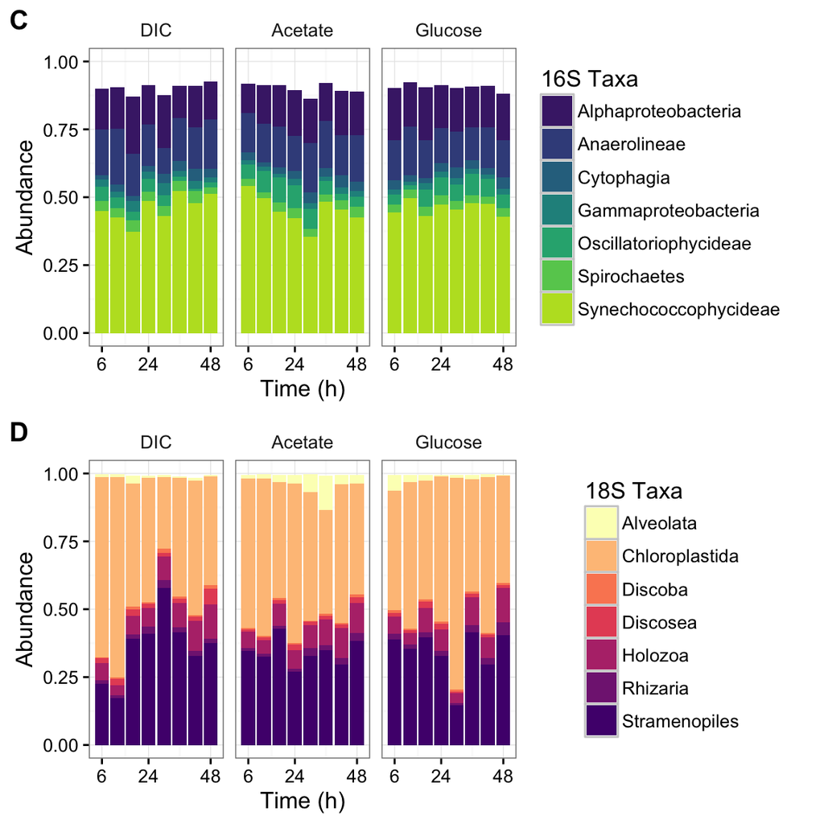

```r
plot_grid(fig1.c, fig1.d, align = "v", ncol = 1, labels = c("C", "D"))
```

```r
# hight should match fig1-ab
# width of both should add up to 183
ggsave('fig1-cd.pdf', path = "./figures/", units = "mm", width = 122, height = 122, scale = 1.4)
```

## Beta Diversity

Usually, UniFrac distances are used to characterize beta diversity. Because I’m not confident of the intricacies of building ML trees from an MSA made from the 18S amplicon, I’ll use Bray-Curtis dissimilarities for everything.

Beta diversity is explored later using the biplot, but here we will be using to access the uniformity of the mat and our biological replicates.

This question is related to this analysis:

> How homogenous were the mats regarding the microbial diversity? How did the variation in community composition from the samples influence the microcosm experiment? Were enough replicates performed to outweigh this effect?

We can explore sources of variation several ways:

1. Compare variation between our technical reps and biologically different samples
2. Look at initial timepoints (T0 and T1) and compare magnitude of difference between samples. (Imperfect, as substrate has already been added.)

#### 1) Compare variation between our technical reps and biologically different samples

```r
df = as(sample_data(rar.16s.cohort), "data.frame")
d = distance(rar.16s.cohort, "bray")
adonis(d ~ Substrate + timepoint + rep., df, permutations = 9999)
```

```
##
## Call:
## adonis(formula = d ~ Substrate + timepoint + rep., data = df,      permutations = 9999)
##
## Permutation: free
## Number of permutations: 9999
##
## Terms added sequentially (first to last)
##
##           Df SumsOfSqs  MeanSqs F.Model      R2 Pr(>F)
## Substrate  2   0.09132 0.045662  4.1298 0.09686 0.0001 ***
## timepoint  7   0.22631 0.032330  2.9241 0.24002 0.0001 ***
## rep.       2   0.00607 0.003034  0.2744 0.00644 0.9997
## Residuals 56   0.61918 0.011057         0.65669
## Total     67   0.94288                  1.00000
## ---
## Signif. codes:  0 '***' 0.001 '**' 0.01 '*' 0.05 '.' 0.1 ' ' 1
```

```r
df = as(sample_data(rar.18s.cohort), "data.frame")
d = distance(rar.18s.cohort, "bray")
adonis(d ~ Substrate + timepoint + rep., df, permutations = 9999)
```

```
##
## Call:
## adonis(formula = d ~ Substrate + timepoint + rep., data = df,      permutations = 9999)
##
## Permutation: free
## Number of permutations: 9999
##
## Terms added sequentially (first to last)
##
##           Df SumsOfSqs  MeanSqs F.Model      R2 Pr(>F)
## Substrate  2   0.31744 0.158722  5.5559 0.12108 0.0001 ***
## timepoint  7   0.70340 0.100486  3.5174 0.26829 0.0001 ***
## rep.       2   0.02968 0.014841  0.5195 0.01132 0.9825
## Residuals 55   1.57126 0.028568         0.59931
## Total     66   2.62179                  1.00000
## ---
## Signif. codes:  0 '***' 0.001 '**' 0.01 '*' 0.05 '.' 0.1 ' ' 1
```

The measurable effect of the technical rep is negligible compared to the effect of Substrate and timepoint.

#### 2) Look at initial timepoints (T0 and T1) and compare magnitude of difference between samples.

Imperfect, as substrate has already been added.

Often in this analysis, the pairwise beta diversity matrix is used as input to an ordination. In this case, I’m going to look at the distribution of Bray–Curtis dissimilarities directly.

```r
rar.16s %>% sample_data() %>% select(timepoint) %>% table
```

```
## .
## T0 T1 T2 T3 T4 T5 T6 T7 T8
##  3 12 12 12 12 10 10 12 12
```

```r
#bray.16s.zero = ordinate(rar.16s.zero, method = "PCoA", distance = "bray")
#plot_ordination(rar.16s.zero, bray.16s.zero, color="Substrate", shape = "timepoint") + geom_line()

# 16s
rar.16s.zero <- subset_samples(rar.16s, timepoint %in% c("T0", "T1"))
distance(rar.16s.zero, "bray") %>% as.list %>% unlist() %>% summary()
```

```
##    Min. 1st Qu.  Median    Mean 3rd Qu.    Max.
## 0.05273 0.11627 0.14150 0.13724 0.16105 0.21209
```

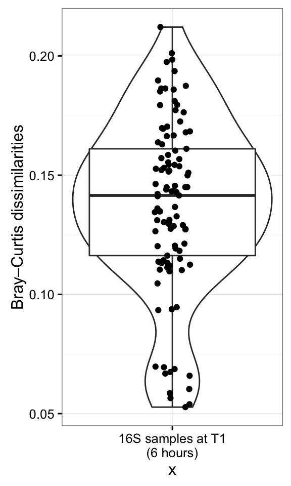

```r
distance(rar.16s.zero, "bray") %>% as.list %>% as.data.frame() %>% melt() %>%
  ggplot(mapping = aes(x = "16S samples at T1\n(6 hours)", y = value)) +
  labs(y = "Bray–Curtis dissimilarities") +
  geom_violin() + geom_boxplot() + geom_jitter(width = .2)
```

```r
# 18s
rar.18s.zero <- subset_samples(rar.18s, timepoint %in% c("T0", "T1"))
distance(rar.18s.zero, "bray") %>% as.list %>% unlist() %>% summary()
```

```
##    Min. 1st Qu.  Median    Mean 3rd Qu.    Max.
## 0.08841 0.23122 0.26532 0.26115 0.31355 0.38545
```

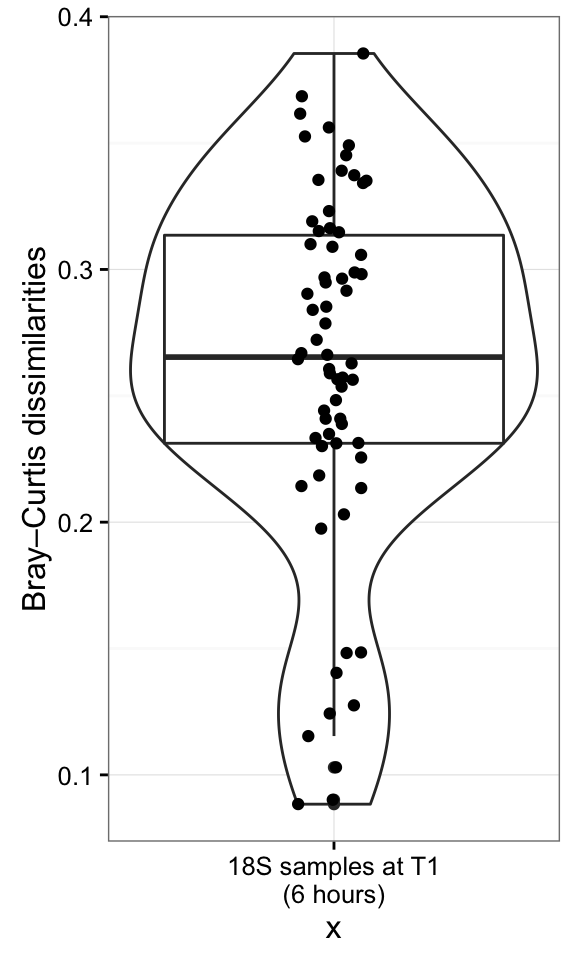

```r
distance(rar.18s.zero, "bray") %>% as.list %>% as.data.frame() %>% melt() %>%
  ggplot(mapping = aes(x = "18S samples at T1\n(6 hours)", y = value)) +
  labs(y = "Bray–Curtis dissimilarities") +
  geom_violin() + geom_boxplot() + geom_jitter(width = .2)
```

So even after 6 hours of incubation, the 16s community has just started to respond to substrate, while the 18S is much more variable.

## Alpha diversity

This function extends phyloseq::estimate_richness() function by implementing two evenness metrics. See this PR https://github.com/joey711/phyloseq/pull/575

```r
estimate_richness_mod <- function(physeq, split=TRUE, measures=NULL){

  if( !any(otu_table(physeq)==1) ){
      # Check for singletons, and then warning if they are missing.
      # These metrics only really meaningful if singletons are included.
        warning(
            "The data you have provided does not have\n",
            "any singletons. This is highly suspicious. Results of richness\n",
            "estimates (for example) are probably unreliable, or wrong, if you have already\n",
            "trimmed low-abundance taxa from the data.\n",
            "\n",
            "We recommended that you find the un-trimmed data and retry."
        )
    }

    # If we are not splitting sample-wise, sum the species. Else, enforce orientation.
    if( !split ){
        OTU <- taxa_sums(physeq)
    } else if( split ){
        OTU <- as(otu_table(physeq), "matrix")
        if( taxa_are_rows(physeq) ){ OTU <- t(OTU) }
    }

    # Define renaming vector:
    renamevec = c("Observed", "Chao1", "ACE", "Shannon", "Pielou", "Simpson", "InvSimpson", "SimpsonE", "Fisher")
    names(renamevec) <- c("S.obs", "S.chao1", "S.ACE", "shannon", "pielou", "simpson", "invsimpson", "simpsone", "fisher")
    # If measures was not explicitly provided (is NULL), set to all supported methods
    if( is.null(measures) ){
      measures = as.character(renamevec)
    }
  # Rename measures if they are in the old-style
  if( any(measures %in% names(renamevec)) ){
    measures[measures %in% names(renamevec)] <- renamevec[names(renamevec) %in% measures]
  }

  # Stop with error if no measures are supported
  if( !any(measures %in% renamevec) ){
    stop("None of the `measures` you provided are supported. Try default `NULL` instead.")
  }

  # Initialize to NULL
  outlist = vector("list")
    # Some standard diversity indices
  estimRmeas = c("Chao1", "Observed", "ACE")
    if( any(estimRmeas %in% measures) ){
    outlist <- c(outlist, list(t(data.frame(estimateR(OTU)))))
    }
    if( "Shannon" %in% measures ){
    outlist <- c(outlist, list(shannon = diversity(OTU, index="shannon")))
    }
  if( "Pielou" %in% measures){
    #print("Starting Pielou")
    outlist <- c(outlist, list(pielou = diversity(OTU, index = "shannon")/log(estimateR(OTU)["S.obs",])))
  }
    if( "Simpson" %in% measures ){
      outlist <- c(outlist, list(simpson = diversity(OTU, index="simpson")))
    }
    if( "InvSimpson" %in% measures ){
      outlist <- c(outlist, list(invsimpson = diversity(OTU, index="invsimpson")))
    }
  if( "SimpsonE" %in% measures ){
    #print("Starting SimpsonE")
    outlist <- c(outlist, list(simpsone = diversity(OTU, index="invsimpson")/estimateR(OTU)["S.obs",]))
  }
    if( "Fisher" %in% measures ){
    fisher = tryCatch(fisher.alpha(OTU, se=TRUE),
      warning=function(w){
        warning("phyloseq::estimate_richness: Warning in fisher.alpha(). See `?fisher.fit` or ?`fisher.alpha`. Treat fisher results with caution")
        suppressWarnings(fisher.alpha(OTU, se=TRUE)[, c("alpha", "se")])
      }
    )
    if(!is.null(dim(fisher))){
      colnames(fisher)[1:2] <- c("Fisher", "se.fisher")
      outlist <- c(outlist, list(fisher))
    } else {
      outlist <- c(outlist, Fisher=list(fisher))
    }
    }
  out = do.call("cbind", outlist)
  # Rename columns per renamevec
  namechange = intersect(colnames(out), names(renamevec))
  colnames(out)[colnames(out) %in% namechange] <- renamevec[namechange]
  # Final prune to just those columns related to "measures". Use grep.
  colkeep = sapply(paste0("(se\\.){0,}", measures), grep, colnames(out), ignore.case=TRUE)
  out = out[, sort(unique(unlist(colkeep))), drop=FALSE]
  # Make sure that you return a data.frame for reliable performance.
  out <- as.data.frame(out)
    return(out)
}
```

Now, let’s use our modified richness function.

```r
metrics <- c("Observed", "SimpsonE")
rich.16s <- estimate_richness_mod(rar.16s.cohort, measures = metrics)
rich.18s <- estimate_richness_mod(rar.18s.cohort, measures = metrics)

# Rename for graphing
graphnames <- c("Richness", "Evenness")
names(rich.16s) <- graphnames
names(rich.18s) <- graphnames


# merge richness with metadata
DF.16s <- merge(rich.16s, sample_data(rar.16s.cohort), by = 0)
DF.18s <- merge(rich.18s, sample_data(rar.18s.cohort), by = 0)

# melt for graphing
reshapevars <- c("Richness", "Evenness")
mdf.16s = melt(DF.16s, measure.vars = graphnames)
mdf.18s = melt(DF.18s, measure.vars = graphnames)
#head(mdf.16s)

mdf.16s$Time..H.num <- as.numeric(mdf.16s$Time..H.)
mdf.18s$Time..H.num <- as.numeric(mdf.18s$Time..H.)
```

### Figure 2: Alpha over time

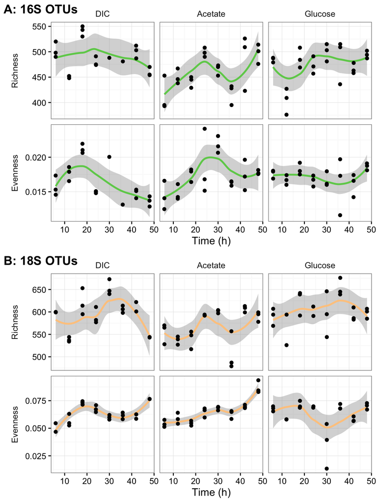

```r
alpha.16s.alt <- ggplot(mdf.16s, aes(Time..H., value))
alpha.16s.alt <- alpha.16s.alt +
  geom_smooth(color = viridis(n = 10)[8]) +
  geom_jitter(width = 0.1) +
  facet_grid(facets = variable~Substrate, scales = "free_y", switch = "y") +
  labs(x = "Time (h)"
       #, title = "16S OTUs"
       ) +
  theme(legend.position = "none",
            strip.background = element_blank(),
            axis.title.y = element_blank()
            #, plot.margin=unit(c(5,5,-25,5), units = "pt")
            )
#alpha.16s.alt

alpha.18s.alt <- ggplot(mdf.18s, aes(Time..H., value))
alpha.18s.alt <- alpha.18s.alt +
  geom_smooth(color = magma(n = 10)[9]) +
  geom_jitter(width = 0.1) +
  facet_grid(facets = variable~Substrate, scales = "free_y", switch = "y") +
  labs(x = "Time (h)"
       #, title = "18S OTUs"
       ) +
  theme(legend.position = "none",
            strip.background = element_blank(),
            axis.title.y = element_blank()
            #axis.text.y = element_blank()
            #, plot.margin=unit(c(5,5,-25,5), units = "pt")
            )
#alpha.18s.alt

plot_grid(alpha.16s.alt, alpha.18s.alt,
          #labels = c("A", "B"),
          labels = c("A: 16S OTUs", "B: 18S OTUs"),
          align = "v", ncol = 1, hjust = -0.05)
```

```r
ggsave('fig2-1col.pdf', path = "./figures/", units = "mm", width = 89, height = 120, scale = 1.7)
```

### Additional analysis of alpha diverisity

This is the same graphs from above, using Shannon and Pielou’s indexes.

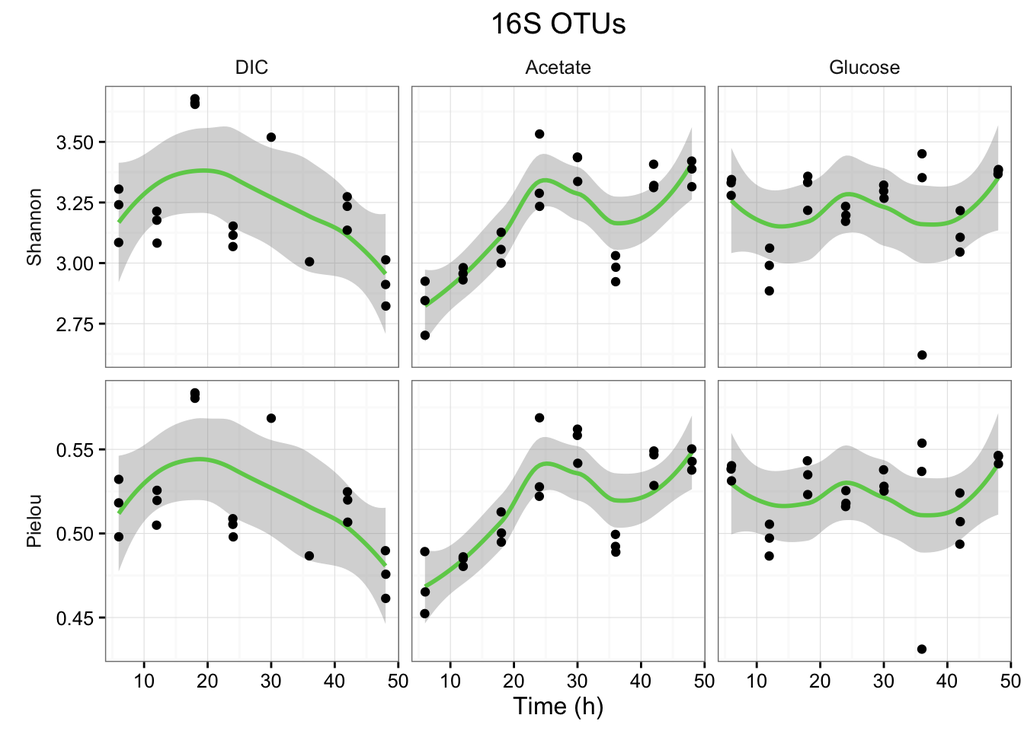

```r
rich.16s.alt <- estimate_richness_mod(rar.16s.cohort, measures = c("Shannon", "Pielou"))
rich.18s.alt <- estimate_richness_mod(rar.18s.cohort, measures = c("Shannon", "Pielou"))

# Rename for graphing
graphnames <- c("Shannon", "Pielou")
names(rich.16s.alt) <- graphnames
names(rich.18s.alt) <- graphnames

# merge richness with metadata
DF.16s.alt <- merge(rich.16s.alt, sample_data(rar.16s.cohort), by = 0)
DF.18s.alt <- merge(rich.18s.alt, sample_data(rar.18s.cohort), by = 0)

DF.16s.alt = melt(DF.16s.alt, measure.vars = graphnames)
DF.18s.alt = melt(DF.18s.alt, measure.vars = graphnames)
#head(mdf.16s)

DF.16s.alt$Time..H.num <- as.numeric(DF.16s.alt$Time..H.)
DF.18s.alt$Time..H.num <- as.numeric(DF.18s.alt$Time..H.)


ggplot(DF.16s.alt, aes(Time..H., value)) +
  geom_smooth(color = viridis(n = 10)[8]) +
  geom_jitter(width = 0.1) +
  facet_grid(facets = variable~Substrate, scales = "free_y", switch = "y") +
  labs(x = "Time (h)", title = "16S OTUs") +
  theme(legend.position = "none",
            strip.background = element_blank(),
            axis.title.y = element_blank())
```

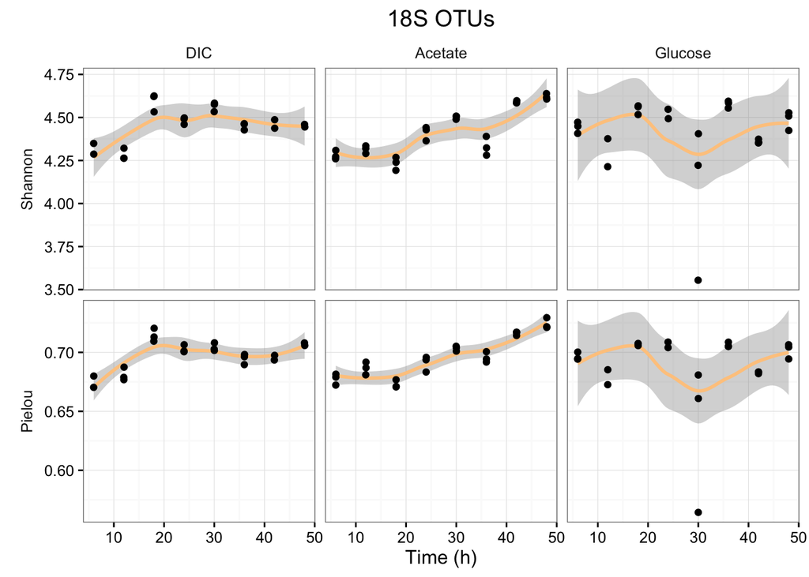

```r
ggplot(DF.18s.alt, aes(Time..H., value)) +
  geom_smooth(color = magma(n = 10)[9]) +
  geom_jitter(width = 0.1) +
  facet_grid(facets = variable~Substrate, scales = "free_y", switch = "y") +
  labs(x = "Time (h)", title = "18S OTUs") +
  theme(legend.position = "none",
            strip.background = element_blank(),
            axis.title.y = element_blank())
```

#### Alpha over time stat test

Because `n` within each group is small, let’s test for equal variance.

Then, use a classic `anova()` test on each combination of Substrate and alpha.

```r
# For testing
df <- filter(mdf.16s, Substrate == "Glucose", variable == "Evenness")
#table(df$timepoint)

runLevene <- function(df){
  t <- leveneTest(value ~ timepoint, data = df) # hardcoded to my data
  t
  return(t$`Pr(>F)`[1])
}

#by(mdf.16s, INDICES = list(mdf.16s$Substrate, mdf.16s$variable), runLevene)
#by(mdf.18s, INDICES = list(mdf.18s$Substrate, mdf.18s$variable), runLevene)

# Smallest number if for 18S, Glucose:Evenness with p = 0.126, so we are good to go!

runANOVA <- function(df){
  res <- lm(value ~ timepoint, data = df) # hardcoded to my data
  a <-  anova(res)
  a
  a$`Pr(>F)`[1]
  #summary(res)
  #TukeyHSD(aov(res), "timepoint") # we don't need to preform a post-hoc test
  return(a$`Pr(>F)`[1])
}

# Outputs

kable(
  tibble(
  Substrate = c("DIC", "Acetate", "Glucose",
                "DIC", "Acetate", "Glucose"),
  variable = c("Richness", "Richness", "Richness",
               "Evenness", "Evenness", "Evenness"),
  `ANOVA p-value` = c(
    by(mdf.16s, INDICES = list(mdf.16s$Substrate, mdf.16s$variable), runANOVA)
    )
)
)
```

| Substrate | variable | ANOVA p-value |
| --- | --- | --- |
| DIC | Richness | 0.0000086 |
| Acetate | Richness | 0.0041506 |
| Glucose | Richness | 0.0016277 |
| DIC | Evenness | 0.0000028 |
| Acetate | Evenness | 0.0152349 |
| Glucose | Evenness | 0.5163856 |

```r
kable(
  tibble(
  Substrate = c("DIC", "Acetate", "Glucose",
                "DIC", "Acetate", "Glucose"),
  variable = c("Richness", "Richness", "Richness",
               "Evenness", "Evenness", "Evenness"),
  `ANOVA p-value` = c(
    by(mdf.18s, INDICES = list(mdf.18s$Substrate, mdf.18s$variable), runANOVA)
    )
)
)
```

| Substrate | variable | ANOVA p-value |
| --- | --- | --- |
| DIC | Richness | 0.0000250 |
| Acetate | Richness | 0.0000647 |
| Glucose | Richness | 0.0791450 |
| DIC | Evenness | 0.0000304 |
| Acetate | Evenness | 0.0000003 |
| Glucose | Evenness | 0.0014949 |

### Figure 3: Alpha over Irradiance

This set of graph shows `alpha ~ Light` only for during the day, when there is light. (Many samples were taking during night, and these have been dropped.)

```r
# color code by time, SOLR on the x axis

# See above
lm_eqn_solar = function(df){
    m = lm(value ~ SOLR.W.m.m, df) # Hardcoded to my data
    m
    summary(m)$coefficients[8]
    if(summary(m)$coefficients[8] < 0.001) {
      outputp <- "0.001"
    }else{
      outputp <- round(summary(m)$coefficients[8], digits = 3)
    }
    eq <- substitute(
      atop("slope ="~slope, "p-value ="~pr), # Two lines
      #"slope ="~slope~","~~R^2~"="~r2, # One line
      list(slope = signif(summary(m)$coefficients[2], digits = 3),
           pr = outputp)
    )
    as.character(as.expression(eq))
}


mdf.16s.light <- subset(mdf.16s, SOLR.W.m.m > 0)
mdf.18s.light <- subset(mdf.18s, SOLR.W.m.m > 0)

eqns <- by(mdf.16s.light, INDICES = list(mdf.16s.light$Substrate, mdf.16s.light$variable), lm_eqn_solar)
eqns

df2 <- data.frame(eq = c(eqns),
                  Substrate = c("DIC", "Acetate", "Glucose",
                                "DIC", "Acetate", "Glucose"),
                  variable = c("Richness", "Richness", "Richness",
                               "Evenness", "Evenness", "Evenness"),
                  graphx = rep(c(320, 400, 400), 2),
                  graphy = c(420, 420, 420, .0225, .013, .013))
df2


alpha.16s.light.only <- ggplot(mdf.16s.light, aes(SOLR.W.m.m, value))
alpha.16s.light.only <- alpha.16s.light.only +
  #geom_boxplot(color = "gray", outlier.size = 0) +
  geom_smooth(method = "lm", color = viridis(n = 10)[8]) +
  geom_jitter(width = 0) +
  facet_grid(facets = variable~Substrate, scales = "free_y", switch = "y") +
  labs(x = expression("Irradiance ("~ Wm^{-2}~ ")")) +
  geom_text(data = df2, aes(x = graphx, y = graphy, label = eq), color = '#777777', parse = TRUE) +
  #v.c + # also add color = Time..H.num to aes() to use this
  theme(legend.position = "right",
        strip.background = element_blank(),
        axis.title.y = element_blank()
        #, plot.margin=unit(c(5,5,-25,5), units = "pt")
        #strip.text.y = element_text(hjust = 2, vjust = .5) # for aligning the facet labs()
        )
alpha.16s.light.only
```

```r
eqns <- by(mdf.18s.light, INDICES = list(mdf.18s.light$Substrate, mdf.18s.light$variable), lm_eqn_solar)
eqns

df2 <- data.frame(eq = c(eqns),
                  Substrate = c("DIC", "Acetate", "Glucose",
                                "DIC", "Acetate", "Glucose"),
                  variable = c("Richness", "Richness", "Richness",
                               "Evenness", "Evenness", "Evenness"),
                  graphx = rep(c(350, 400, 420), 2),
                  graphy = c(520, 520, 520, .025, .025, .025))
df2

alpha.18s.light.only <- ggplot(mdf.18s.light, aes(SOLR.W.m.m, value))
alpha.18s.light.only <- alpha.18s.light.only +
  geom_smooth(method = "lm", color = magma(n = 10)[9]) +
  geom_jitter(width = 0) +
  facet_grid(facets = variable~Substrate, scales = "free_y", switch = "y") +
  labs(x = expression("Irradiance ("~ Wm^{-2}~ ")")) +
  geom_text(data = df2, aes(x = graphx, y = graphy, label = eq), color = '#777777', parse = TRUE) +
  theme(legend.position = "right",
        strip.background = element_blank(),
        axis.title.y = element_blank()
        )
alpha.18s.light.only
```

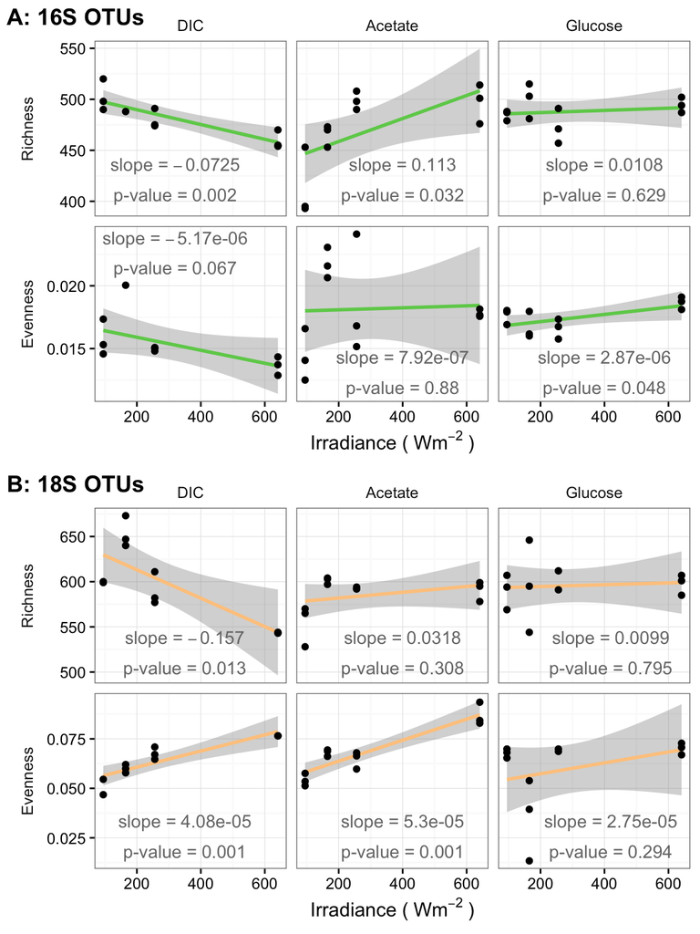

```r
plot_grid(alpha.16s.light.only, alpha.18s.light.only,
          labels = c("A: 16S OTUs", "B: 18S OTUs"),
          align = "v", ncol = 1, hjust = -0.05)
```

```r
#ggsave('fig3-1.5col.pdf', path = "./figures/", units = "mm", width = 120, height = 160, device = cairo_pdf, scale = 1.3)
ggsave('fig3-1col.pdf', path = "./figures/", units = "mm", width = 89, height = 120, scale = 1.7)
```

### Figure 4: Alpha over productivity

```r
# Let's see if we can add slopes and p-values to these graphs
# See https://stackoverflow.com/questions/17022553/adding-r2-on-graph-with-facets
# Example data for testing function
df <- mdf.16s[mdf.16s$Substrate == "Acetate" & mdf.16s$variable == "Richness", ]
dim(df)
lm_eqn_deltac = function(df){
    m = lm(value ~ fin_diff_Ave_d13C.organic, df) # Hardcoded to my data
    m
    summary(m)$coefficients[2]
    eq <- substitute(
      atop("slope ="~slope, "p-value ="~pr), # Two lines
      #"slope ="~slope~","~~R^2~"="~r2, # One line
      list(slope = signif(summary(m)$coefficients[2], digits = 3),
           pr = round(summary(m)$coefficients[8], digits = 3))
    )
    as.character(as.expression(eq))
}

# Make a matching data frame with these calculated values
# This is based on the stackoverflow answer, and on the Bile Acids graphs
# See Lactobacillus acidophilus disrupts multispecies synthesis of a secondary bile acid ursocholate
# Hans C. Bernstein, PNNL, 2017

eqns <- by(mdf.16s, INDICES = list(mdf.16s$Substrate, mdf.16s$variable), lm_eqn_deltac)
#eqns

df2 <- data.frame(eq = c(eqns),
                  Substrate = c("DIC", "Acetate", "Glucose",
                                "DIC", "Acetate", "Glucose"),
                  variable = c("Richness", "Richness", "Richness",
                               "Evenness", "Evenness", "Evenness"),
                  graphx = c(0, 20, 60, -0.21, 40, 60),
                  graphy = c(430, 430, 430, .020, .020, .020))
#df2

alpha.16s.1 <- ggplot(mdf.16s, aes(fin_diff_Ave_d13C.organic, value))
alpha.16s.1 <- alpha.16s.1 +
  #geom_boxplot(color = "gray", outlier.size = 0) +
  geom_smooth(method = "lm", color = viridis(n = 10)[8]) +
  geom_jitter(width = 0) +
  facet_grid(facets = variable~Substrate, scales = "free", switch = "y") +
  labs(x = expression("Productivity: " ~ Delta~delta^13~C / Delta ~t ~"  (‰"~ h^-1~")")) +
  #v.c + # also add color = Time..H.num to aes() to use this
  geom_text(data = df2, aes(x = graphx, y = graphy, label = eq), color = '#777777', parse = TRUE) +
  theme(legend.position = "right",
        strip.background = element_blank(),
        axis.title.y = element_blank()
        #, plot.margin=unit(c(5,5,-25,5), units = "pt")
        #strip.text.y = element_text(hjust = 2, vjust = .5) # for aligning the facet labs()
        )
alpha.16s.1
```

```r
eqns <- by(mdf.18s, INDICES = list(mdf.18s$Substrate, mdf.18s$variable), lm_eqn_deltac)
#eqns

df2 <- data.frame(eq = c(eqns),
                  Substrate = c("DIC", "Acetate", "Glucose",
                                "DIC", "Acetate", "Glucose"),
                  variable = c("Richness", "Richness", "Richness",
                               "Evenness", "Evenness", "Evenness"),
                  graphx = rep(c(0, 30, 50), 2),
                  graphy = c(540, 650, 540, .025, .025, .025))
#df2


alpha.18s.1 <- ggplot(mdf.18s, aes(fin_diff_Ave_d13C.organic, value))
alpha.18s.1 <- alpha.18s.1 +
  geom_smooth(method = "lm", color = magma(n = 10)[9]) +
  geom_jitter(width = 0) +
  facet_grid(facets = variable~Substrate, scales = "free", switch = "y") +
  labs(x = expression("Productivity: " ~ Delta~delta^13~C / Delta ~t ~"  (‰"~ h^-1~")")) +
  #v.c + # also add color = Time..H.num to aes() to use this
  geom_text(data = df2, aes(x = graphx, y = graphy, label = eq), color = '#777777', parse = TRUE) +
  theme(legend.position = "right",
        strip.background = element_blank(),
        axis.title.y = element_blank()
        )
alpha.18s.1
```

```r
#alpha.18s.1 + geom_smooth(method = "lm", aes(color = Substrate)) + scale_color_brewer(palette = "Set2")
```

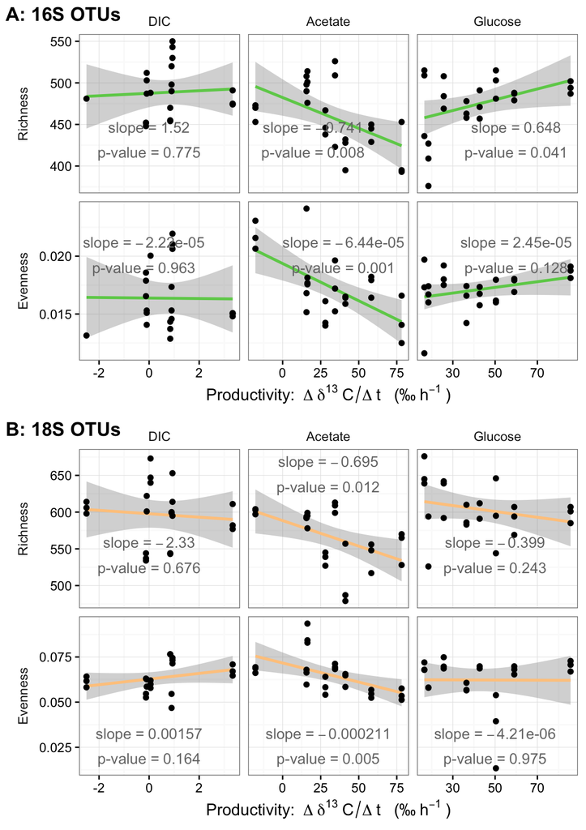

```r
plot_grid(alpha.16s.1, alpha.18s.1,
          labels = c("A: 16S OTUs", "B: 18S OTUs"),
          align = "v", ncol = 1, hjust = -0.05)
```

```r
#ggsave('fig4-1.5col.pdf', path = "./figures/", units = "mm", width = 120, height = 160, device = cairo_pdf, scale = 1.3)
ggsave('fig4-1col.pdf', path = "./figures/", units = "mm", width = 89, height = 120, scale = 1.7)
```

##### Other alpha graphs…

…where made, but are not included in the final document.

## RA graphs for bioplot

Taxa, merged at the Family level, will be use as vectors in the biplot. (Note that the stacked bar plot shows taxa at the Class level.)

```r
# Glom OTUs and transform to RA
glom.16s <- tax_glom(rar.16s.cohort, taxrank = "Rank5")
glom.16s <- transform_sample_counts(glom.16s, function(x) x / sum(x))

# Take top taxa
glom.16s.top <- prune_taxa(names(sort(taxa_sums(glom.16s), TRUE))[0:10], glom.16s)
glom.16s.top
sum(taxa_sums(glom.16s.top)) / sum(taxa_sums(glom.16s))

# plot!
plot_bar(glom.16s.top, x = "Time..H.", fill = "Rank5", facet_grid = ~Substrate)
```

```r
tax_table(glom.16s.top)


## 18S
glom.18s <- tax_glom(rar.18s.cohort, taxrank = "Rank5")
glom.18s <- transform_sample_counts(glom.18s, function(x) x / sum(x))

glom.18s.top <- prune_taxa(names(sort(taxa_sums(glom.18s), TRUE))[0:10], glom.18s)
glom.18s.top
sum(taxa_sums(glom.18s.top)) / sum(taxa_sums(glom.18s))

glom.18s.top
sum(taxa_sums(glom.18s.top)) / sum(taxa_sums(glom.18s))

plot_bar(glom.18s.top, x = "Time..H.", fill = "Rank5", facet_grid = ~Substrate)
```

Goal: for each sample (row) of the metadata table, I want to add columns with the abundance of microbes at a given taxonomy level.

```r
# 16S
glom.16s.top.table <- as.data.frame(otu_table(glom.16s.top))
row.names(glom.16s.top.table) <- as.data.frame(tax_table(glom.16s.top))$Rank5

glom.16s.top.meta <- cbind((sample_data(glom.16s.top)), t(glom.16s.top.table))
head(glom.16s.top.meta)

# Add these taxa back into a new phyloseq object
rar.16s.w_tax <- rar.16s.cohort
sample_data(rar.16s.w_tax) <- glom.16s.top.meta


# 18S
glom.18s.top.table <- as.data.frame(otu_table(glom.18s.top))
row.names(glom.18s.top.table) <- as.data.frame(tax_table(glom.18s.top))$Rank5

glom.18s.top.meta <- cbind((sample_data(glom.18s.top)), t(glom.18s.top.table))
head(glom.18s.top.meta)

rar.18s.w_tax <- rar.18s.cohort
sample_data(rar.18s.w_tax) <- glom.18s.top.meta

# Test graphs
ggplot(glom.16s.top.meta, aes(Time..H., f__Pseudanabaenaceae)) + geom_point() + facet_grid(~Substrate)
```

```r
ggplot(glom.18s.top.meta, aes(Time..H., D_4__Vampyrellidae)) + geom_point() + facet_grid(~Substrate)
```

Use the `phyloseq` wrapper of `vegan::capscale()`

```r
dist.16s <- phyloseq::distance(rar.16s.w_tax, method = "bray", type = "samples")
dist.18s <- phyloseq::distance(rar.18s.w_tax, method = "bray", type = "samples")

# basic plot to make sure this works:
# Test 16s names
plot(capscale(dist.16s ~ Time..H. + SOLR.W.m.m +
                       Substrate
                     #+ Ave_d13C.organic + fin_diff_Ave_d13C.organic +
                  #     f__Rhodospirillaceae + f__Phormidiaceae + f__Spirochaetaceae + f__Saprospiraceae + f__A4b + f__Rhodobacteraceae + f__Hyphomonadaceae + f__Pseudanabaenaceae + f__Cyclobacteriaceae + f__Anaerolineaceae
                     ,
                     data.frame(sample_data(rar.16s.w_tax))))
```

```r
# Names work great! Let's test new productivity vectors
plot(capscale(dist.16s ~ Time..H. + SOLR.W.m.m +
                pp + hpa + hpg,
                     data.frame(sample_data(rar.16s.w_tax))), col=sample_data(rar.16s.w_tax)$Substrate)
```

```r
plot(capscale(dist.16s ~ Time..H. + SOLR.W.m.m +
                fin_diff_Ave_d13C.organic + Substrate,
                     data.frame(sample_data(rar.16s.w_tax))),
     #col=c("red","blue","green")[sample_data(rar.16s.w_tax)$Substrate]
     col="blue"
     )
```

```r
# Ordinate
#cap.16s = ordinate(rar.16s.w_tax, "CAP", dist.16s,
#                   ~ Time..H. + SOLR.W.m.m +
#                     Substrate + fin_diff_Ave_d13C.organic +
#                     f__Rhodospirillaceae + f__Phormidiaceae + f__Spirochaetaceae + f__Saprospiraceae + f__A4b + f__Rhodobacteraceae + f__Hyphomonadaceae + f__Pseudanabaenaceae + f__Cyclobacteriaceae + f__Anaerolineaceae)

cap.16s = ordinate(rar.16s.w_tax, "CAP", dist.16s,
                   ~ Time..H. + SOLR.W.m.m +
                     pp + hpa + hpg +
                     f__Rhodospirillaceae + f__Phormidiaceae + f__Spirochaetaceae + f__Saprospiraceae + f__A4b + f__Rhodobacteraceae + f__Hyphomonadaceae + f__Pseudanabaenaceae + f__Cyclobacteriaceae + f__Anaerolineaceae)

# Two alternative ordinations. These show that choice of carbon variable does not change ordination much
#cap.16s = ordinate(rar.16s.w_tax, "CAP", dist.16s,
#                   ~ Time..H. + SOLR.W.m.m +
#                     fin_diff_Ave_d13C.organic +
#                     f__Rhodospirillaceae + f__Phormidiaceae + f__Spirochaetaceae + f__Saprospiraceae + f__A4b + f__Rhodobacteraceae + f__Hyphomonadaceae + f__Pseudanabaenaceae + f__Cyclobacteriaceae + f__Anaerolineaceae)

#cap.16s = ordinate(rar.16s.w_tax, "CAP", dist.16s,
#                   ~ Time..H. + SOLR.W.m.m +
#                     #fin_diff_Ave_d13C.organic +
#                     f__Rhodospirillaceae + f__Phormidiaceae + f__Spirochaetaceae + f__Saprospiraceae + f__A4b + f__Rhodobacteraceae + f__Hyphomonadaceae + f__Pseudanabaenaceae + f__Cyclobacteriaceae + f__Anaerolineaceae)

# 18S
cap.18s = ordinate(rar.18s.w_tax, "CAP", dist.18s,
                   ~ Time..H. + SOLR.W.m.m +
                     pp + hpa + hpg +
                     D_4__Chrysophyceae + D_4__Thraustochytriaceae + D_5__Codonosigidae + D_4__Blastocystis + D_9__Podocopa + D_4__uncultured.eukaryote + D_6__Bacillariophyceae + D_10__Solanales + D_11__Alismatales + D_4__Vampyrellidae)

# Add length vector
cap16s.v <- data.frame(cap.16s$CCA$biplot)
# The find the length (magnitude) of the vbectors in the first two dimentions
cap16s.v$length1and2 <-sqrt(cap16s.v$CAP1^2+cap16s.v$CAP2^2)
#cap16s.v[order(cap16s.v$length1and2, decreasing = T),]

cap18s.v <- data.frame(cap.18s$CCA$biplot)
cap18s.v$length1and2 <-sqrt(cap18s.v$CAP1^2+cap18s.v$CAP2^2)

#cap16s.v <- cap16s.v[order(cap16s.v$length1and2),]
#cap18s.v <- cap18s.v[order(length1and2),]


# This is a great place to improve names.
row.names(cap16s.v) <- gsub("f__", "", row.names(cap16s.v), fixed = T)
row.names(cap16s.v)[1:2] <- c("Time (h)", "Irradiance")
row.names(cap16s.v)[3:5] <- c("NPP", "NHPa", "NHPg")
# Improve lable for Anaerolineae
row.names(cap16s.v)[10] <- "Anaerolineae A4b"
#                        c__Anaerolineae o__SBR1031 f__A4b

row.names(cap18s.v) <- gsub("D.*_", "", row.names(cap18s.v))
row.names(cap18s.v)[1:2] <- c("Time (h)", "Irradiance")
row.names(cap18s.v)[3:5] <- c("NPP", "NHPa", "NHPg")
# Fix name of Solanales (of order of flowering plants). The taxa database (SILVA ) places this in Chloroplastida,
# so we will report this at the class level, instead of the overly specific family level.
row.names(cap18s.v)[13] <- "Chloroplastida"

# Add vector categories
tmp.vector.categories <- c("Environment", "Environment",
                           "Productivity", "Productivity", "Productivity",
                           rep("Taxa", nrow(cap16s.v)-5))
length(tmp.vector.categories)
cap16s.v$category <- tmp.vector.categories
cap18s.v$category <- tmp.vector.categories


# compare relative lengths of vectors
ggplot(cap16s.v, aes(x = category, y = length1and2, color = category)) + geom_boxplot() + geom_point()
```

```r
ggplot(cap18s.v, aes(x = category, y = length1and2, color = category)) + geom_boxplot() + geom_point()
```

```r
# environment is one of the least important factors

# People like circles around the db-RDA vectors. So, here, have a circle:
# From http://stackoverflow.com/questions/6862742/draw-a-circle-with-ggplot2
circleFun <- function(center = c(0,0), radius = 1, npoints = 100){
    r = radius
    tt <- seq(0, 2*pi, length.out = npoints)
    xx <- center[1] + r * cos(tt)
    yy <- center[2] + r * sin(tt)
    return(data.frame(x = xx, y = yy))
}
#geom_path will do open circles, geom_polygon will do filled circles
#plot + geom_path(aes(x = x, y=y), data = circleFun(c(0,0), 1, 100), color="grey")
```

The bi-plot:

```r
# Without vectors, showing off substrate clustering
plot <- plot_ordination(rar.16s.w_tax, cap.16s, "samples", shape="Substrate", color = "Substrate")
#plot +
#  geom_path(aes(x = x, y = y, shape = NULL), data = circleFun(c(0,0), 1, 100), color="lightgrey") +
#  scale_color_brewer(palette = "Set2")


plot.16s <- plot_ordination(rar.16s.w_tax, cap.16s, "samples", shape = "Substrate")
plot.16s <- plot.16s + geom_point(color = "lightgrey") +
    geom_path(aes(x = x, y=y, shape = NULL), data = circleFun(c(0,0), 1, 100), color="lightgrey") +
    geom_segment(data = cap16s.v, aes(x = 0, xend = CAP1, y = 0, yend = CAP2, color = category, shape = NULL),
                 arrow = arrow(length = unit(0.25, "cm"))) +
    geom_text_repel(segment.size = 0, max.iter = 2000, box.padding = unit(0.2, "lines"),
                    data = cap16s.v, aes(x=CAP1, y=CAP2, label=row.names(cap16s.v), color = category, shape = NULL), size = 4
                        #,color = cap16s.v$color, color="black"
                        ) +
  theme(legend.position = "none") +
  labs(title = "16S OTUs")
plot.16s
```

```r
plot.18s <- plot_ordination(rar.18s.w_tax, cap.18s, "samples", shape = "Substrate")
plot.18s <- plot.18s + geom_point(color = "lightgrey") +
    geom_path(aes(x = x, y=y, shape = NULL), data = circleFun(c(0,0), 1, 100), color="lightgrey") +
    geom_segment(data = cap18s.v, aes(x = 0, xend = CAP1, y = 0, yend = CAP2, color = category, shape = NULL),
                 arrow = arrow(length = unit(0.25, "cm"))) +
    geom_text_repel(segment.size = 0, max.iter = 2000, box.padding = unit(0.2, "lines"), data = cap18s.v,
                    aes(x=CAP1, y=CAP2, label=row.names(cap18s.v), color = category, shape = NULL), size = 4
                        #,color = cap16s.v$color, color="black"
                        ) +
  labs(title = "18S OTUs", color = "Vector")
plot.18s
```

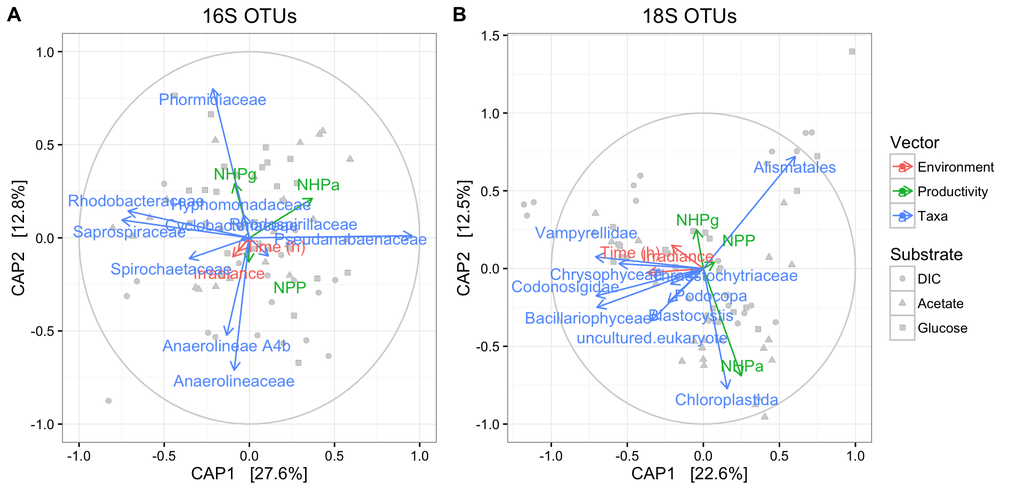

```r
plot_grid(plot.16s, plot.18s,
          labels = c("A", "B"),
          align = "h", nrow = 1, rel_widths = c(1, 1.3))
```

```r
ggsave('fig5-2col.pdf', path = "./figures/", units = "mm", width = 183, height = 82, scale = 1.4)
```

```r
# Save and Knit the document early.
knitr::knit_exit(append = F)
```

FALSE